# Machine Learning - presentation

Katarzyna Jałbrzykowska

05 June 2022

# Regression - traffic dataset

## Data preparation

In the first step, we loaded the data. Then they were checked if any missing observations are present within the data. We also analyzed the structure and type of the variables.

```r
traffic_train=read.csv(file="traffic_train.csv",sep=",",header=TRUE)
traffic_test=read.csv(file="traffic_test.csv",sep=",",header=TRUE)
```

The first column - the date of observation with an accuracy of an hour was converted to the datetime data type.

Instead of using the index column, we created features describing each time characteristic: hour, month, year, yearweek (which might represent information about holidays), weekday, weekend and date.

Our train dataset covers the period between 2014-10-01 and 2018-12-31, consists of 1223 days, giving 29701 observations total.

The weather conditions are described by two variables: weather_general and weather_detailed. The detailed feature includes 37 levels which are very similar to the general variable levels. In addition, some of the levels are very small, which could affect the results’ bias. For this reason, we have decided not to use the weather_detailed characteristic, which should also reduce possible overfitting of the model.

All variables which were stored as characters were converted to factors.

We also changed the type of the variable Year to numeric.

Most of the observations represented a good weather. However, we merged similar events: levels “Smoke” and “Haze” and “Squall” and “Thunderstorm”, which are usually very extreme weather events.

After checking the structure of the yearweek feature, we noticed that only a few observations were recorded in the last week of the year (no. 53), we combined this level with the no. 52.

We found one outlier in our traffic dataset - with the temperature below -200C. We decided to remove this observation, as it was most likely an error.

```r
out_temp <- which(traffic_train_train$temperature > -200)
traffic_train_train <- traffic_train_train[out_temp,]
```

## Feature engeneering

#### Box-Cox transformation

To transform our positively skewed dependent variable to a relatively symmetrical distribution, we used a Box-Cox transformation.

```r
traffic_boxcox <- boxcox(traffic_train_train$traffic +1, standardize = FALSE)
```

Our optimal lambda:

```
## [1] 0.6703624
```

We can compare the results of transformation below. Although the new distribution is not ideally symmetrical, the predictive power of our model should still improve.

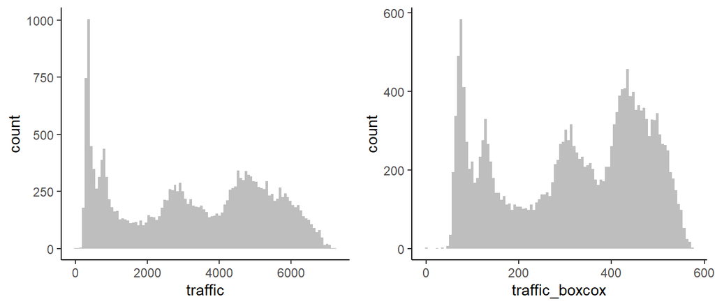

#### Features binning

We used the cut() function to divide the following variables into bigger groups: clouds_coverage_pct, months and time.

As for the clouds_coverage_pct, we divided the observations into groups based on their quantiles. The final intervals were as following: [0,1], (1,40], (40,75], (75,90], (90,100].

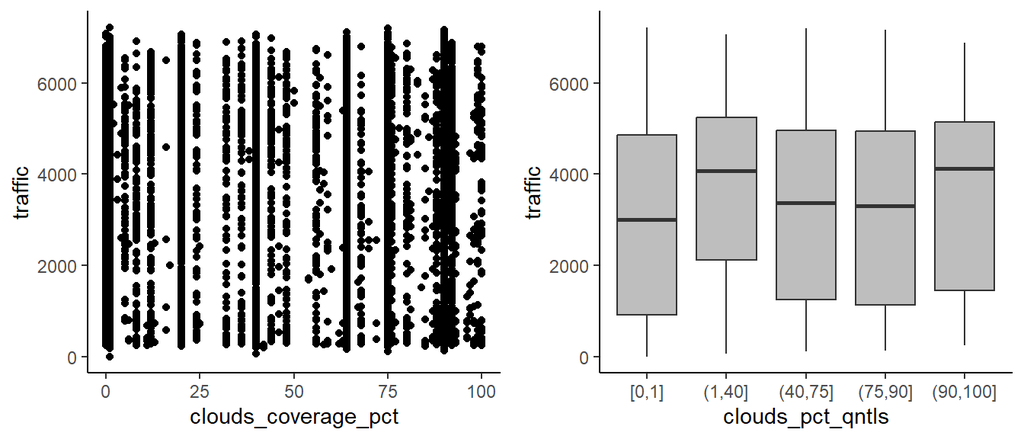

The feature Month was divided into the 4 natural seasons: spring, summer, fall and winter. We also checked if the months had similar traffic mean for each season.

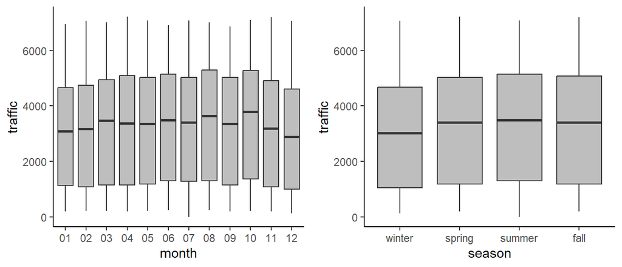

The binning of the time feature was based on the graph and mean traffic values analysis. We decided to create five levels: “morning”,“midday”,“afternoon”,“evening” and “night”, corresponding with the following hours: 6-10,11-14,15-17,18-21,22-5.

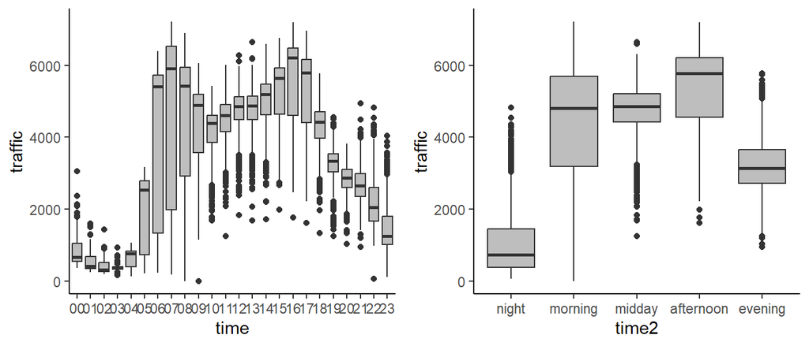

## Final model

The best results were estimated using a model with grouped features and a feature describing yearweeks (which probably represented the effect on holidays on traffic).

```r
selected3 <- c("weather_general2","clouds_pct_qntls", "temperature", "rain_mm",
               "time2", "season", "year", "weekend","traffic", "traffic_boxcox", "yearweek")
```

#### Time series cross-validation

```r
options(contrasts = c("contr.treatment",  # for non-ordinal factors
                      "contr.treatment")) # for ordinal factors

myTimeControl <- trainControl(method = "timeslice",
                              initialWindow = 6000,
                              horizon = 2000,
                              fixedWindow = TRUE,
                              skip=3000)
```

#### KNN

During the process of model selection we run the linear models using different features, the KNN models with the k-parametr optimization, and the LASSO and elastic Net model. The interpretation of the results was not straightforward. For MAPE, the KNN model turned out to be optimal. On the other hand, it achieved a small R2 as well as high absolute errors. If we took a different measure as selection criteria, then probably the linear model would be the optimal one.

For our KNN model, first We tried a very wide range of k values - from 1 to 150 (corresponding with a size of our data). In the second step we narrowed it and at the end we decided to keep the KNN model with k=8.

```r
different_k3b <- data.frame(k = seq(1,20, 1))

traffic_knn3b <-
  train(traffic_boxcox ~ .,
        data = traffic_var3_train %>%
          # we exclude traffic
          dplyr::select(-traffic)
        ,
        # model type - now knn!!
        method = "knn",
        # validation used!
        trControl = myTimeControl,
        # parameters to be compared
        tuneGrid = different_k3b,
        metric = "RMSE",
        preProcess = c("range"))

traffic_knn3b
```

```
## k-Nearest Neighbors
##
## 20369 samples
##     9 predictor
##
## Pre-processing: re-scaling to [0, 1] (75)
## Resampling: Rolling Forecasting Origin Resampling (2000 held-out with a fixed window)
## Summary of sample sizes: 6000, 6000, 6000, 6000, 6000
## Resampling results across tuning parameters:
##
##   k   RMSE       Rsquared   MAE
##    1  113.81298  0.4984339  81.12723
##    2  101.66699  0.5760791  73.87446
##    3   98.38179  0.5989389  71.64230
##    4   96.38177  0.6102690  71.23175
##    5   94.69104  0.6247007  71.02936
##    6   93.24638  0.6354502  70.81287
##    7   92.32992  0.6426080  70.62955
##    8   91.58298  0.6504155  70.55489
##    9   92.86504  0.6392235  72.18161
##   10   92.25393  0.6439020  72.08850
##   11   92.30066  0.6442777  72.49291
##   12   92.13545  0.6475864  72.75667
##   13   92.53339  0.6467386  73.52149
##   14   92.85244  0.6483330  74.30709
##   15   92.75254  0.6525122  74.54504
##   16   92.95847  0.6530886  74.68593
##   17   93.81924  0.6501564  75.58954
##   18   94.39260  0.6481358  76.21984
##   19   94.91477  0.6463836  76.64197
##   20   95.76789  0.6412225  77.47898
##
## RMSE was used to select the optimal model using the smallest value.
## The final value used for the model was k = 8.
```

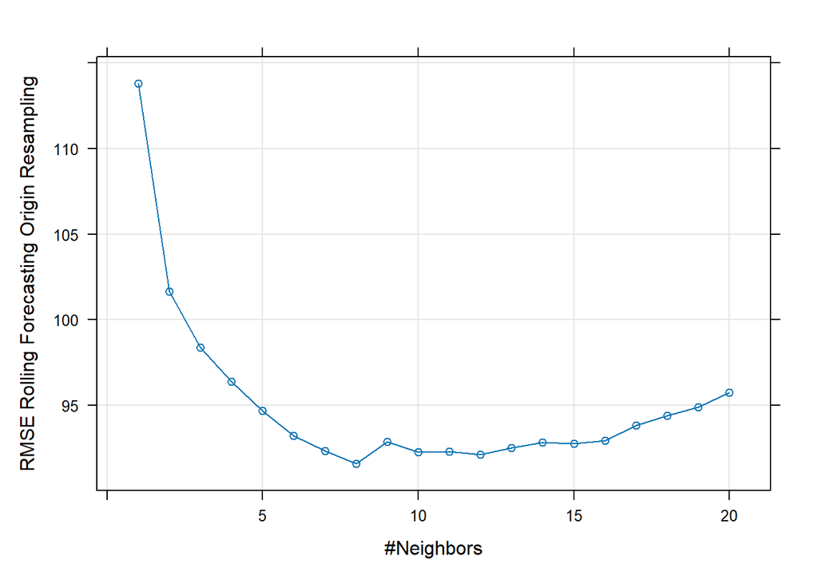

[output not shown]

```r
plot(traffic_knn3b)
```

```r
final_k <- data.frame(k = 8)

traffic_bestModel <-
  train(traffic_boxcox ~ .,
        data = traffic_var3_train %>%
          # we exclude traffic
          dplyr::select(-traffic)
        ,
        # model type - now knn!!
        method = "knn",
        # validation used!
        trControl = myTimeControl,
        # parameters to be compared
        tuneGrid = final_k,
        metric = "RMSE",
        preProcess = c("range"))

traffic_bestModel
```

```
## k-Nearest Neighbors
##
## 20369 samples
##     9 predictor
##
## Pre-processing: re-scaling to [0, 1] (75)
## Resampling: Rolling Forecasting Origin Resampling (2000 held-out with a fixed window)
## Summary of sample sizes: 6000, 6000, 6000, 6000, 6000
## Resampling results:
##
##   RMSE      Rsquared   MAE
##   91.58298  0.6504155  70.55489
##
## Tuning parameter 'k' was held constant at a value of 8
```

The comparison between the predicted and real traffic values, for both the train and the test sample, is presented below:

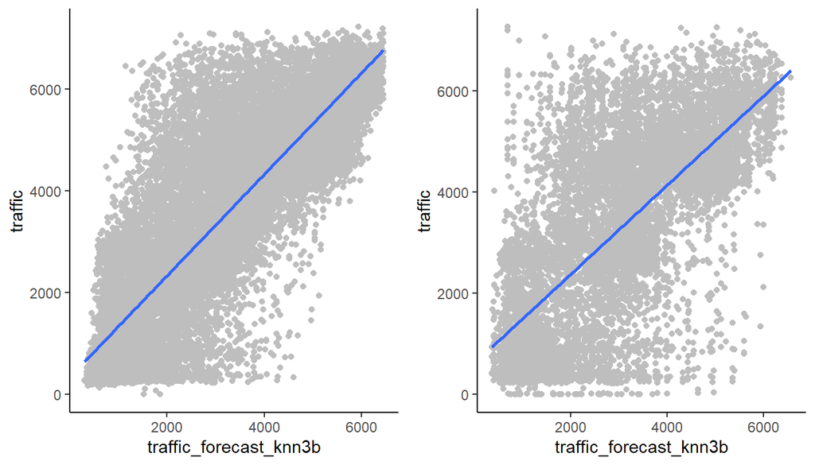

It is worth mentioning that the error measured on the test sample was much higher than on the the training data. Therefore we don’t expect the results to be very accurate, the MAPE will probably be close to 5.

Prediction:

```r
traffic_test$traffic_forecast <-(sapply(predict(traffic_knn3b,traffic_test), function(x){max(0,x)})*traffic_boxcox$lambda+1)^(1/traffic_boxcox$lambda)
```